# Lecture Notes

### Writing vectorized codes:

```r
negabs1 <- function(x) {
  if (x <= 0) {
    return(x)
  }
  if (x > 0) {
    return(-x)
  }
}

negabs1(5)
```

```
[1] -5
```

```r
negabs1(-1)
```

```
[1] -1
```

```r
# negabs1(c(2, -3)) it won't work since it's just for a single number


negabs2 <- function(x) {
  out <- vector(length = length(x))
  for (i in 1:length(x)) {
    out[i] <- if (x[i] <= 0) {
      x[i]
    } else {
      -x[i]
    }
  }
  return(out)
}


negabs2(-1)
```

```
[1] -1
```

```r
negabs2(5)
```

```
[1] -5
```

```r
negabs2(c(2, 6, -1, 0, 3, -1))
```

```
[1] -2 -6 -1  0 -3 -1
```

```r
# Using for loops
negabs3 <- function(x) {
  out <- c()
  for (i in 1:length(x)) {
    out <- c(out,
             if (x[i] <= 0) {
               x[i]
             } else {
               -x[i]
             }
    )
  }
  return(out)
}

negabs3(-1)
```

```
[1] -1
```

```r
negabs3(5)
```

```
[1] -5
```

```r
negabs3(c(2, 6, -1, 0, 3, -1))
```

```
[1] -2 -6 -1  0 -3 -1
```

If we compare the run time of the negabs2 and negabs3:

```r
microbenchmark(negabs2(-1000:1000),
               negabs3(-1000:1000))
```

```
Unit: microseconds
                expr      min       lq     mean    median         uq       max
 negabs2(-1000:1000)  130.301  140.751  165.567  152.1005   167.5505   536.301
 negabs3(-1000:1000) 4398.901 5847.851 8153.651 6419.4510 10666.7015 20503.001
 neval cld
   100  a
   100   b
```

```r
# Also write another function
negabs4 <- function(x) {
  -abs(x)
}

microbenchmark(negabs2(-1000:1000),
               negabs3(-1000:1000),
               negabs4(-1000:1000))
```

```
Unit: microseconds
                expr      min       lq       mean   median        uq       max
 negabs2(-1000:1000)  133.101  138.301  158.78900  148.001  159.4510   305.002
 negabs3(-1000:1000) 4426.400 5036.251 6974.37011 5916.502 6769.8510 19246.701
 negabs4(-1000:1000)    1.801    2.502   19.02702    4.601   11.2015  1174.100
 neval cld
   100  a
   100   b
   100  a
```

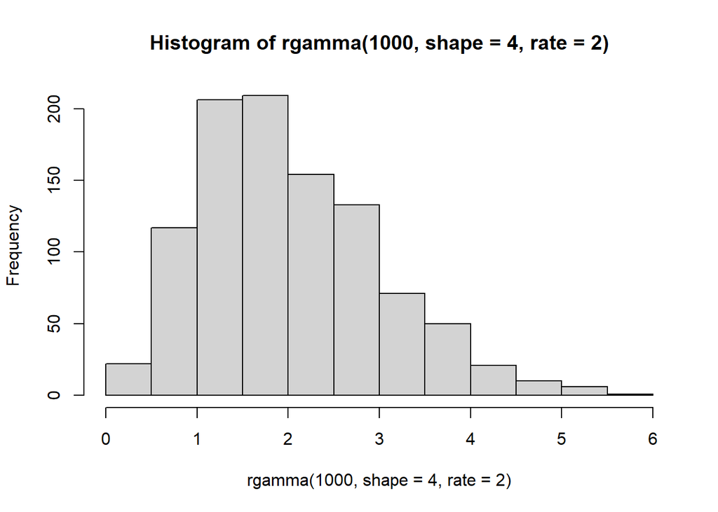

```r
hist(rgamma(1000, shape = 4, rate = 2))
```

```r
sample(5:73, 10, replace = TRUE)
```

```
 [1]  6 45 52 18 10 22  8 64 55 42
```

```r
sample(c(0, 1), 10, replace = TRUE)
```

```
 [1] 1 0 0 0 1 1 0 1 1 0
```

```r
set.seed(20240910)
sample(c(0, 1), 10, replace = TRUE)
```

```
 [1] 0 0 1 1 0 1 0 0 1 0
```

```r
sample(c(0, 1), 10, replace = TRUE)
```

```
 [1] 0 0 0 1 0 0 1 0 1 1
```

Estimating pi example:

```r
#' Estimate pi
#' @param n number of Monte Carlo draws
#' @return an estimate of pi
estimate_pi <- function(n) {
  xcoords <- runif(n, -1, 1)
  ycoords <- runif(n, -1, 1)
  in_circle <- sqrt(xcoords^2 + ycoords^2) <= 1
  return(4*sum(in_circle)/n)
}
estimate_pi(1000000)
```

```
[1] 3.140136
```

## Sep 12th

### Statistics

We can access the quantiles of our datasets:

```r
n <- 10000
df <- 3
dat <- rt(n,df)

save <- vector(length=n)
for (i in 1:n){
  save[i] <- dat[i] < -1.96
}

odat <- dat[order(dat)]

# Now we order our values
head(dat, n=10)
```

```
 [1]  1.581997798 -0.096567821 -0.009706411 -0.055118045  1.437141414
 [6]  0.181583926 -0.563009011  0.353699637 -0.843594291 -3.125732609
```

```r
head(odat, n=10)
```

```
 [1] -29.96289 -19.99006 -18.95421 -18.51686 -13.69306 -13.38899 -12.84867
 [8] -12.56014 -12.33965 -12.32236
```

```r
# We have 3 degrees of freedom so we need to use .975*n and .025*n
odat[round(.975*n)]
```

```
[1] 3.211204
```

```r
odat[round(.025*n)]
```

```
[1] -3.121217
```

If we generate a new set of data and find the confidence intervals:

```r
reps <- 15
n <- 10000
sims <- rt(reps*n, df=df)
msim <- matrix(sims, nrow=n)

means <- apply(msim, 2, mean)
sds <- apply(msim, 2, sd)/sqrt(n)

critical <- abs(qt(.025, 3))  # getting the critical values
print(critical)
```

```
[1] 3.182446
```

```r
lb <- means - critical*sds
ub <- means + critical*sds

# Now check the confidence intervals that include 0
coverage <- lb<0 & ub>0
mean(coverage)  # We see that it's basically full coverage.
```

```
[1] 1
```

If we prefer working with matrices:

```r
a <- matrix(1:8, nrow=2)

cat("The original matrix takes form: \n")
```

```
The original matrix takes form:
```

```r
print(a)
```

```
     [,1] [,2] [,3] [,4]
[1,]    1    3    5    7
[2,]    2    4    6    8
```

```r
a+1
```

```
     [,1] [,2] [,3] [,4]
[1,]    2    4    6    8
[2,]    3    5    7    9
```

```r
cat("We can shift the entire matrix by a+1: \n")
```

```
We can shift the entire matrix by a+1:
```

```r
print(a+1)
```

```
     [,1] [,2] [,3] [,4]
[1,]    2    4    6    8
[2,]    3    5    7    9
```

```r
cat("R uses column dominant matrices, it will apply shifts repeatedly columnwise, e.g. c(1,10): \n")
```

```
R uses column dominant matrices, it will apply shifts repeatedly columnwise, e.g. c(1,10):
```

```r
print(a + c(1,10))
```

```
     [,1] [,2] [,3] [,4]
[1,]    2    4    6    8
[2,]   12   14   16   18
```

```r
cat("If we want them to be row dominant, we can take a double transpose: \n")
```

```
If we want them to be row dominant, we can take a double transpose:
```

```r
print(t(t(a) + c(1,10)))
```

```
     [,1] [,2] [,3] [,4]
[1,]    2   13    6   17
[2,]    3   14    7   18
```

Let’s work on an example:

```r
n <- 50
m <- 200
r <- .5
y <- rnorm(n)
xmat <- matrix(rep(y, times=m), nrow=n)
xmat <- r*xmat + rnorm(n*m, sd=sqrt(1-r^2.))

savedcor <- vector(length=m)

# We can do it with a for loop:
for (i in 1:m){
  savedcor[i] = cor(y, xmat[, i])
}
mean(savedcor)
```

```
[1] 0.5041032
```

```r
# Or we can vectorize by using apply:
savedcor2=apply(xmat, 2, function(k) cor(y,k))
mean(savedcor2)  # the results are the same
```

```
[1] 0.5041032
```

```r
xm <- colMeans(xmat)
xsd <- apply(xmat, 2, sd)
xmat2 <- xmat - matrix(rep(xm, each=n), nrow=n)
xsd <- apply(xmat2, 2, sd)
xmat3 <- xmat2/matrix(rep(xsd, each=n), nrow=n)
y2 <- (y-mean(y))/sd(y)

xm <- colMeans(xmat)
xmat2 <- t(t(xmat)-xm)
xsd <- sqrt(colSums(xmat2^2)/(n-1))
xmat3 <- t(t(xmat2)/xsd)
y2 <- (y-mean(y))/sd(y)
savedcor3 <- as.vector(y2 %*% xmat3)/(n-1)
mean(savedcor3)
```

```
[1] 0.5041032
```

```r
print("The results from different methods are the same")
```

```
[1] "The results from different methods are the same"
```

### Function coding

Following what we had for the statistics section, now we write some function:

```r
coveragesim <- function(reps, n, df, afunc){
  sims <- rt(reps*n, df=df)
  msim <- matrix(sims, nrow=n)
  means <- apply(msim, 2, mean)
  sds <- apply(msim, 2, sd)/sqrt(n)
  critical <- abs(qt(.025, df))
  lb <- means - critical*sds
  ub <- means + critical*sds

  coverage <- lb<0 & ub>0
  return(mean(coverage))
}
coveragesim(reps, n, df)
```

```
[1] 1
```

## Sep 17

### Debugging

Double arrows are used to store local variables in function as global variables.

```r
somefunc <- function(x,y,z){
  sum_local <- x+y+z
  sum_global <<- x+y+z
  print(sum_local, sum_global)
}
somefunc(1,2,3)
```

```
[1] 6
```

```r
print("We can see the the sum_global is stored in the global environment")
```

```
[1] "We can see the the sum_global is stored in the global environment"
```

There is a function named browser which allows us to do debugging inside the local environment:

```r
somefunc <- function(x,y,z){
  browser()
  mean_val = mean(c(x,y,z))
  sum_local <- x+y+z
}
somefunc(1,2,3)
```

```
Called from: somefunc(1, 2, 3)
debug at <text>#3: mean_val = mean(c(x, y, z))
debug at <text>#4: sum_local <- x + y + z
```

We can also debug functionals (functions in functions):

```r
foo <- function(){
  # We can use browsers() function to browse the loops.
  boo()
}

boo <- function(){
  doo()
}

doo <- function(){
  m <- c(1,2)
  return(m[3])
}
foo()
```

```
[1] NA
```

```r
traceback()
```

```
No traceback available
```

## Sep 19

### Profiling

When the code is running, profiling will give you a status of your function. We see three things, the code, the frame graph, and the data view. They basically show the same things: the memory and run time.

```r
library(profvis)

# Set parameters
n <- 300
m <- 100000
r <- .4

# generate data
y <- rnorm(n)
xmat <- matrix(rep(y, times = m), ncol = m)
xmat <- r * xmat + rnorm(n * m, sd = sqrt(1 - r^2))

# Standardize x's
profvis({
  rmn <- colMeans(xmat)
  xmat_c <- xmat - matrix(rep(rmn, each = n), ncol = m)
  rsd <- sqrt(colSums(xmat_c^2) / (n - 1))
  #rsd <- apply(xmat, 2, sd)
  xmat_s <- xmat_c / matrix(rep(rsd, each = n), ncol = m)

  # standardize y
  y_s <- (y - mean(y)) / sd(y)

  # results
  r3 <- y_s %*% xmat_s / (n - 1)
  r3 <- as.vector(r3)
})
```

[interactive chart not shown]

### Matrix operations

```r
c(1,2) + c(2, 3, 4)  # It will be elementwise, so it's 1+2, 2+3, 1+4
```

```
[1] 3 5 5
```

```r
c(1, 2, 3) + c(1, 2)  # It is also elementwise, so it is 1+1, 2+2, 3+1
```

```
[1] 2 4 4
```

```r
c(1, 2, 3) + 4  # It will add 4 to all of them
```

```
[1] 5 6 7
```

```r
c(1, 2, 3) + c(4)  # Same as above, because it will be elementwise
```

```
[1] 5 6 7
```

```r
c(1, 2) + mean(c(1, 2, 3))  # mean of an array is also a number
```

```
[1] 3 4
```

```r
result <- c(1, 2) * matrix(1:6, nrow = 2)
if (all(dim(result) != c(2,3))) {
  stop("error")
}
matrix(c(1, 2), nrow = 1) %*% matrix(1:6, nrow = 2)  # %*% for matrix operations
```

```
     [,1] [,2] [,3]
[1,]    5   11   17
```

```r
#matrix(c(1, 2), nrow = 1) * matrix(1:6, nrow = 2)  it will throw an error because by default, it will be elementwise
```

### Linear regression models

Now we want to know how the models and model fitting works for R. We use the example of the mtcars dataset again.

```r
data(mtcars)

form <- qsec ~ disp + cyl  # we are modeling the outcome with variables
# qsec = beta_0 + beta_1*disp + beta_2*cyl + epsilon
# RHS :  disp + cyl
# LHS: qsec
```

The linear regression model is given by lm:

```r
lm(form, data = mtcars)
```

```
Call:
lm(formula = form, data = mtcars)

Coefficients:
(Intercept)         disp          cyl
  22.716347     0.007708    -1.074113
```

```r
lm(qsec ~ disp + cyl, data = mtcars)
```

```
Call:
lm(formula = qsec ~ disp + cyl, data = mtcars)

Coefficients:
(Intercept)         disp          cyl
  22.716347     0.007708    -1.074113
```

In addition to variables, we can do other things to manipulate how our models work. If we want to remove the intercept, both +0 and -1 will do thing job:

```r
lm(qsec ~ disp + cyl + 0, data = mtcars)
```

```
Call:
lm(formula = qsec ~ disp + cyl + 0, data = mtcars)

Coefficients:
    disp       cyl
-0.04999   4.58365
```

```r
lm(qsec ~ disp + cyl - 1, data = mtcars)
```

```
Call:
lm(formula = qsec ~ disp + cyl - 1, data = mtcars)

Coefficients:
    disp       cyl
-0.04999   4.58365
```

We also have other ways for fitting data:

```r
lm(qsec ~ disp * cyl, data = mtcars)  # This * means considering the interaction given by this product.
```

```
Call:
lm(formula = qsec ~ disp * cyl, data = mtcars)

Coefficients:
(Intercept)         disp          cyl     disp:cyl
  18.945088     0.040484    -0.597213    -0.004159
```

```r
lm(qsec ~ disp : cyl, data = mtcars)  # This : means we only want to consider the interaction term.
```

```
Call:
lm(formula = qsec ~ disp:cyl, data = mtcars)

Coefficients:
(Intercept)     disp:cyl
 19.0496669   -0.0007408
```

```r
lm(qsec ~ disp + cyl + disp : cyl, data = mtcars)  # This does the same thing as the first line, but in more details.
```

```
Call:
lm(formula = qsec ~ disp + cyl + disp:cyl, data = mtcars)

Coefficients:
(Intercept)         disp          cyl     disp:cyl
  18.945088     0.040484    -0.597213    -0.004159
```

```r
lm(qsec ~ disp * cyl * mpg, data = mtcars)  # Now we include all the 3 pieces and all the interactions.
```

```
Call:
lm(formula = qsec ~ disp * cyl * mpg, data = mtcars)

Coefficients:
 (Intercept)          disp           cyl           mpg      disp:cyl
  -23.719738      0.403733      6.103585      2.040372     -0.052748
    disp:mpg       cyl:mpg  disp:cyl:mpg
   -0.016068     -0.345405      0.002221
```

```r
lm(qsec ~ disp + cyl + disp:cyl + disp:mpg + cyl:mpg + disp:cyl:mpg,
   data = mtcars)  # If we don't want the mpg fit, we can write out the terms explicitly.
```

```
Call:
lm(formula = qsec ~ disp + cyl + disp:cyl + disp:mpg + cyl:mpg +
    disp:cyl:mpg, data = mtcars)

Coefficients:
 (Intercept)          disp           cyl      disp:cyl      disp:mpg
  19.0165627     0.1004277    -1.2174713    -0.0102349    -0.0030437
     cyl:mpg  disp:cyl:mpg
   0.0333434     0.0003045
```

```r
lm(qsec ~ disp * cyl * mpg - mpg, data = mtcars)  # Or we can just remove the term by -.
```

```
Call:
lm(formula = qsec ~ disp * cyl * mpg - mpg, data = mtcars)

Coefficients:
 (Intercept)          disp           cyl      disp:cyl      disp:mpg
  19.0165627     0.1004277    -1.2174713    -0.0102349    -0.0030437
     cyl:mpg  disp:cyl:mpg
   0.0333434     0.0003045
```

```r
lm(qsec ~ ., data = mtcars)  # It includes every term in the dataset.
```

```
Call:
lm(formula = qsec ~ ., data = mtcars)

Coefficients:
(Intercept)          mpg          cyl         disp           hp         drat
  17.776177     0.069048    -0.362678    -0.007501    -0.001563    -0.131064
         wt           vs           am         gear         carb
   1.496332     0.970035    -0.901186    -0.201285    -0.273598
```

```r
mod <- lm(qsec ~ . - am, data = mtcars)  # Everything but the am.
```

If we want to check the details of our linear model, we can see its summary:

```r
smod <- summary(mod)
is(mod)  # It's a list
```

```
[1] "lm"       "oldClass"
```

```r
is(smod)  # It's also a list
```

```
[1] "summary.lm"
```

```r
stats:::print.lm(mod)  # It prints out the details of the list
```

```
Call:
lm(formula = qsec ~ . - am, data = mtcars)

Coefficients:
(Intercept)          mpg          cyl         disp           hp         drat
  18.144145     0.050287    -0.282548    -0.007775    -0.002780    -0.241369
         wt           vs         gear         carb
   1.647968     1.288892    -0.419836    -0.286389
```

```r
mod$coefficients  # The $ pulls contents out
```

```
 (Intercept)          mpg          cyl         disp           hp         drat
18.144144646  0.050287311 -0.282547631 -0.007774568 -0.002779893 -0.241368764
          wt           vs         gear         carb
 1.647968078  1.288892299 -0.419836011 -0.286388904
```

```r
head(mod$fitted.values)  #
```

```
        Mazda RX4     Mazda RX4 Wag        Datsun 710    Hornet 4 Drive
         16.50661          16.92684          19.27950          19.51118
Hornet Sportabout           Valiant
         16.61522          20.09668
```

```r
smod$r.squared  # Also we can pull out things from the summary.
```

```
[1] 0.8605427
```

If we want to get the coefficients, residuals, fitted.values, we have direct functions to call them:

```r
mod$coefficients
```

```
 (Intercept)          mpg          cyl         disp           hp         drat
18.144144646  0.050287311 -0.282547631 -0.007774568 -0.002779893 -0.241368764
          wt           vs         gear         carb
 1.647968078  1.288892299 -0.419836011 -0.286388904
```

```r
smod$coefficients
```

```
                Estimate  Std. Error    t value     Pr(>|t|)
(Intercept) 18.144144646 3.987375043  4.5503983 0.0001572776
mpg          0.050287311 0.062092109  0.8098825 0.4266813985
cyl         -0.282547631 0.296796298 -0.9519918 0.3514440806
disp        -0.007774568 0.005134824 -1.5140867 0.1442392882
hp          -0.002779893 0.006596321 -0.4214308 0.6775296482
drat        -0.241368764 0.485026322 -0.4976405 0.6236750462
wt           1.647968078 0.505747945  3.2584771 0.0035992557
vs           1.288892299 0.550421535  2.3416458 0.0286606519
gear        -0.419836011 0.421416968 -0.9962485 0.3299616199
carb        -0.286388904 0.240146843 -1.1925574 0.2457471211
```

```r
coefficients(mod)
```

```
 (Intercept)          mpg          cyl         disp           hp         drat
18.144144646  0.050287311 -0.282547631 -0.007774568 -0.002779893 -0.241368764
          wt           vs         gear         carb
 1.647968078  1.288892299 -0.419836011 -0.286388904
```

```r
residuals(mod)
```

```
          Mazda RX4       Mazda RX4 Wag          Datsun 710      Hornet 4 Drive
        -0.04661182          0.09315632         -0.66949698         -0.07117750
  Hornet Sportabout             Valiant          Duster 360           Merc 240D
         0.40477667          0.12332023          0.01365743         -0.33121991
           Merc 230            Merc 280           Merc 280C          Merc 450SE
         2.81653984         -0.65626809          0.01413415         -0.51142216
         Merc 450SL         Merc 450SLC  Cadillac Fleetwood Lincoln Continental
         0.20362841          0.62683336          0.27316421         -0.22218231
  Chrysler Imperial            Fiat 128         Honda Civic      Toyota Corolla
        -0.76650642         -0.34183613          0.20210996          0.58616626
      Toyota Corona    Dodge Challenger         AMC Javelin          Camaro Z28
         0.20607167         -0.20630437          0.36414897         -0.76324057
   Pontiac Firebird           Fiat X1-9       Porsche 914-2        Lotus Europa
         0.03629285         -0.21632694         -0.21860363         -0.78954896
     Ford Pantera L        Ferrari Dino       Maserati Bora          Volvo 142E
         0.32371502         -0.19932844          0.59482649         -0.87246761
```

```r
head(predict(mod))
```

```
        Mazda RX4     Mazda RX4 Wag        Datsun 710    Hornet 4 Drive
         16.50661          16.92684          19.27950          19.51118
Hornet Sportabout           Valiant
         16.61522          20.09668
```

```r
head(mod$fitted.values)  # It's the same as predicting.
```

```
        Mazda RX4     Mazda RX4 Wag        Datsun 710    Hornet 4 Drive
         16.50661          16.92684          19.27950          19.51118
Hornet Sportabout           Valiant
         16.61522          20.09668
```

If we want to fit quadratic:

```r
lm(mpg ~ wt*wt, data = mtcars)  # It won't work
```

```
Call:
lm(formula = mpg ~ wt * wt, data = mtcars)

Coefficients:
(Intercept)           wt
     37.285       -5.344
```

```r
# There are several other ways to do it, one is to define the wt^2 directly, though not encouraged:
mtcars$wtsq <- mtcars$wt^2
lm(mpg ~ wt + wtsq, data = mtcars)  # R don't know if wt and wtsq are connected.
```

```
Call:
lm(formula = mpg ~ wt + wtsq, data = mtcars)

Coefficients:
(Intercept)           wt         wtsq
     49.931      -13.380        1.171
```

```r
# Or we can use I, which tells R to use the math:
mod <- lm(mpg ~ wt + I(wt*wt), data = mtcars)
names(mod$coef)
```

```
[1] "(Intercept)" "wt"          "I(wt * wt)"
```